# NYPD Shooting Incident Report Rmd

Taylor J

2024-10-05

# NYPD Shooting Data File Introduction

## Inserting and Formatting the Data

### First, I will start by loading my data.

Hello! This project was done with the **NYPD Shooting Incident Data (Historic)** file located at this [link](https://data.cityofnewyork.us/api/views/833y-fsy8/rows.csv?accessType=DOWNLOAD).

```r
NYPD_df <- "https://data.cityofnewyork.us/api/views/833y-fsy8/rows.csv?accessType=DOWNLOAD"
NYPD_shooting_df <- read_csv(NYPD_df)
```

### Next, I will work on tidying my data.

Let’s eliminate the columns I will not need for this project. Most of the ones we are eliminating are location descriptions which may be helpful if we were looking for the precise area where an incident happened, but since we are given **BORO** and **Longitude/Latitude** the rest are mostly irrelevant for our work.

Below you will see me filter out N/A’s or blanks and replace them with ‘Unknown’. This is because police typically mark unknown races as **O** or **Unknown**. This [link](https://www.dcf.ks.gov/services/PPS/Documents/PPM_Forms/Section_5000_Forms/PPS5460_Instr.pdf) shows the labeling system for the state of Kansas.

```r
NYPD_shooting_df.2 <- NYPD_shooting_df %>% select(2, 3, 4, 10:16, 19:20)
lapply(NYPD_shooting_df.2, function(x) sum(is.na(x)))
```

```
## $OCCUR_DATE
## [1] 0
##
## $OCCUR_TIME
## [1] 0
##
## $BORO
## [1] 0
##
## $STATISTICAL_MURDER_FLAG
## [1] 0
##
## $PERP_AGE_GROUP
## [1] 9344
##
## $PERP_SEX
## [1] 9310
##
## $PERP_RACE
## [1] 9310
##
## $VIC_AGE_GROUP
## [1] 0
##
## $VIC_SEX
## [1] 0
##
## $VIC_RACE
## [1] 0
##
## $Latitude
## [1] 59
##
## $Longitude
## [1] 59
```

```r
NYPD_shooting_df.2 <- NYPD_shooting_df.2 %>% replace_na(list(PERP_AGE_GROUP = "Unknown", PERP_SEX = "Unknown", PERP_RACE = "Unknown"))
```

### After that, I need to format the rest of the **“Unknown”** and the different lines as characters or factors or etc…to finish cleaing up the data!

```r
NYPD_shooting_df.2$PERP_AGE_GROUP = recode(NYPD_shooting_df.2$PERP_AGE_GROUP, UNKNOWN = "Unknown")
NYPD_shooting_df.2$PERP_SEX = recode(NYPD_shooting_df.2$PERP_SEX, U = "Unknown")
NYPD_shooting_df.2$PERP_RACE = recode(NYPD_shooting_df.2$PERP_RACE, UNKNOWN = "Unknown")
NYPD_shooting_df.2$VIC_SEX   = recode(NYPD_shooting_df.2$VIC_SEX, U = "Unknown")
NYPD_shooting_df.2$VIC_RACE   = recode(NYPD_shooting_df.2$VIC_RACE, UNKNOWN = "Unknown")
NYPD_shooting_df.2$BORO = as.factor(NYPD_shooting_df.2$BORO)
NYPD_shooting_df.2$PERP_AGE_GROUP = as.factor(NYPD_shooting_df.2$PERP_AGE_GROUP)
NYPD_shooting_df.2$PERP_SEX = as.factor(NYPD_shooting_df.2$PERP_SEX)
NYPD_shooting_df.2$PERP_RACE = as.factor(NYPD_shooting_df.2$PERP_RACE)
NYPD_shooting_df.2$VIC_AGE_GROUP = as.factor(NYPD_shooting_df.2$VIC_AGE_GROUP)
NYPD_shooting_df.2$VIC_SEX = as.factor(NYPD_shooting_df.2$VIC_SEX)
NYPD_shooting_df.2$VIC_RACE = as.factor(NYPD_shooting_df.2$VIC_RACE)
NYPD_shooting_df.2[(NYPD_shooting_df.2 == '(null)')] <- 'Unknown'
```

### Then, once that is done, we can summarize cleanly and go from there!

```r
summary(NYPD_shooting_df.2)
```

[output not shown]

### Within this summary, we find some values that seem a little extreme.. for example.. no one that I know can be *1022* years old. Let’s clean some of those issues up as well.

```r
NYPD_shooting_df.2 = subset(NYPD_shooting_df.2, PERP_AGE_GROUP!="1020" & PERP_AGE_GROUP!="224" & PERP_AGE_GROUP!="940" & VIC_AGE_GROUP!="1022")
```

### Now that we have eliminated the extremes, we should be set to form our analysis and complementary visuals!

## Visualizing the Data

### 1.) Our first visualization will help us show the relationship between the victims age range, and how many of these incidents occured in that range.

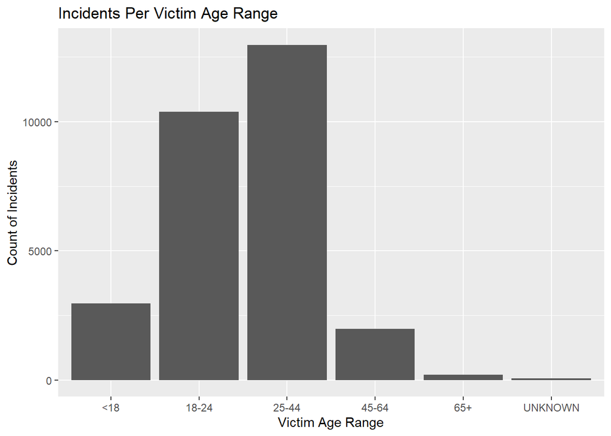

```r
victim_age_gg <- ggplot(NYPD_shooting_df.2, aes(x = VIC_AGE_GROUP)) +
  geom_bar() +
  labs(title = "Incidents Per Victim Age Range",
       x = "Victim Age Range",
       y = "Count of Incidents")
victim_age_gg
```

### 2.) Our second visualization will help show us a relationship between a victim’s age group, and the Borough that the incident occured in.

```r
time_age_gg <- ggplot(NYPD_shooting_df.2, aes(x = OCCUR_TIME)) +
    geom_density() +
    facet_wrap(~ BORO)
  labs(title = 'Victim Age vs Occurance Time',
       x = 'Victim Age',
       y = 'Borough Where Incident Occured')
```

```
## $x
## [1] "Victim Age"
##
## $y
## [1] "Borough Where Incident Occured"
##
## $title
## [1] "Victim Age vs Occurance Time"
##
## attr(,"class")
## [1] "labels"
```

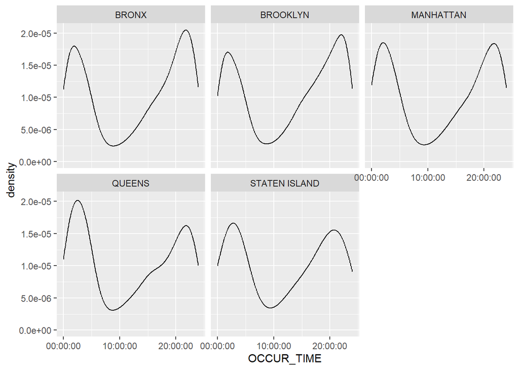

```r
time_age_gg
```

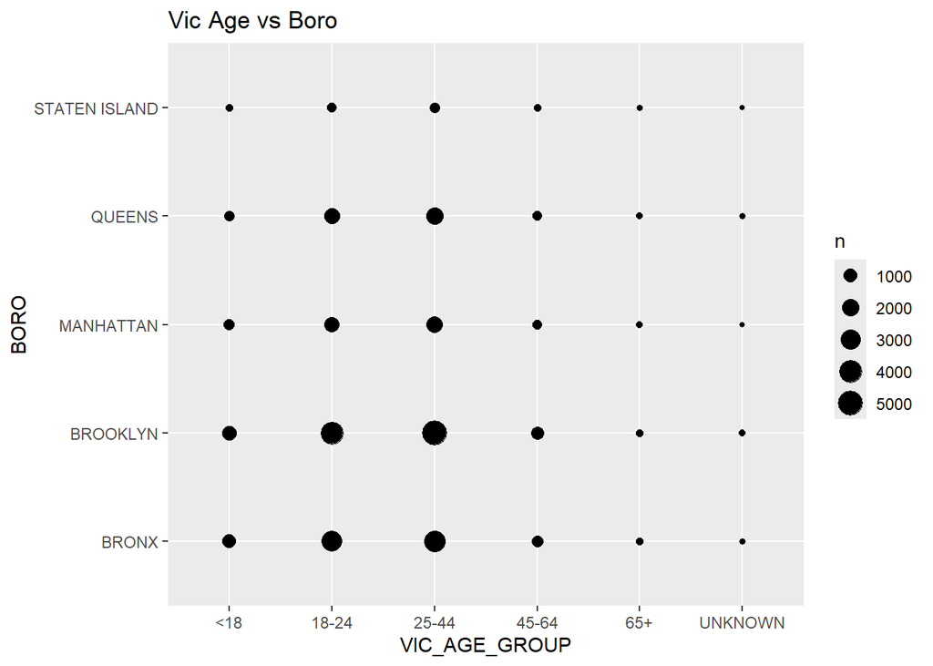

```r
ggplot(NYPD_shooting_df.2, aes(x = VIC_AGE_GROUP, y = BORO)) +
  geom_count() +
  labs(title = 'Vic Age vs Boro')
```

```r
NYPD_lm <- lm(STATISTICAL_MURDER_FLAG ~ VIC_AGE_GROUP, data = NYPD_shooting_df.2)
summary(NYPD_lm)
```

```
##
## Call:
## lm(formula = STATISTICAL_MURDER_FLAG ~ VIC_AGE_GROUP, data = NYPD_shooting_df.2)
##
## Residuals:
##     Min      1Q  Median      3Q     Max
## -0.3220 -0.2188 -0.1666 -0.1303  0.8697
##
## Coefficients:
##                      Estimate Std. Error t value Pr(>|t|)
## (Intercept)          0.130332   0.007239  18.004  < 2e-16 ***
## VIC_AGE_GROUP18-24   0.036287   0.008204   4.423 9.77e-06 ***
## VIC_AGE_GROUP25-44   0.088464   0.008021  11.029  < 2e-16 ***
## VIC_AGE_GROUP45-64   0.118028   0.011425  10.330  < 2e-16 ***
## VIC_AGE_GROUP65+     0.191619   0.028416   6.743 1.58e-11 ***
## VIC_AGE_GROUPUNKNOWN 0.104043   0.049710   2.093   0.0364 *
## ---
## Signif. codes:  0 '***' 0.001 '**' 0.01 '*' 0.05 '.' 0.1 ' ' 1
##
## Residual standard error: 0.3934 on 28552 degrees of freedom
## Multiple R-squared:  0.008311,   Adjusted R-squared:  0.008138
## F-statistic: 47.86 on 5 and 28552 DF,  p-value: < 2.2e-16
```

# Bias?